# Métricas de interés de los equipos aspirantes a ganar la Copa del Mundo Qatar 2022

Rosangel Herrera

2022-11-25

# Panorama previo a la Copa Mundial Qatar 2022

[figure not shown]

El deporte une las masas y la FIFA a través de los años ha reforzado su influencia tanto en el plano deportivo como en el político a través del futbol, el torneo actual en el que asume como sede Qatar no ha sido exento a ello, entre controversias de corrupción, violación de derechos laborales. Qatar hoy en día alberga las 32 selecciones clasificadas en las eliminatorias de las confederaciones continentales con la ilusión de ganar la copa del mundo y representar a su país.

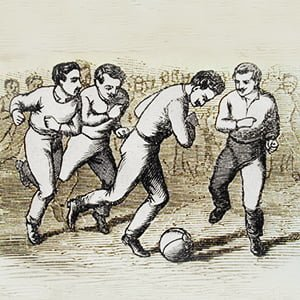

Como parte de la narrativa de este análisis, es necesario conocer un poco más sobre Qatar como nación e ir incorporando el plano futbolístico de las selecciones en este evento. En primer lugar, Qatar “es una Península situada en medio de la costa Occidental y el Golfo Arábigo, entre las latitudes (24,27> y 26.10») Norte, y longitud (50.45» y 51.40») Este. Es una península que se extiende hacia el norte en las aguas del Golfo cubriendo 11,521 kilómetros cuadrados” (MÉRICA DEL SUR-PAÍSES ÁRABES CUMBRE, 2022, p. 13). Su clima es desértico moderado con veranos calientes, en cuanto a su población, esta nación desciende de las antiguas tribus árabes que emigraros de la península de arábiga y conforman un aproximado de 1.5 millones de habitantes.

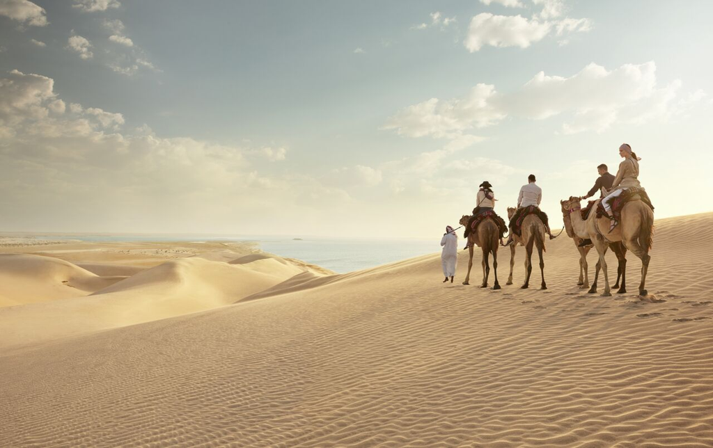

La elección de Qatar como sede ha sido de las mas controvertidas en la historia de la World Cup dado a una serie escándalos y políticas internas del país. Sin embargo, en el “En 2010 Qatar se aseguró los derechos a la Copa del Mundo al ganar una votación de los 22 miembros ejecutivos de la FIFA. El país derrotó las candidaturas de Estados Unidos, Corea del Sur, Japón y Australia, para convertirse en la primera nación árabe en albergar el torneo.” **([BBC](https://www.bbc.com/mundo/noticias-61798823)**, 2022, sp).

[figure not shown]

En total serán ocho las sedes que albergarán los 64 partidos que representa el torneo de la World Cup en un total de cinco ciudades. Con 32 selecciones participantes de las 6 confederaciones continentales.

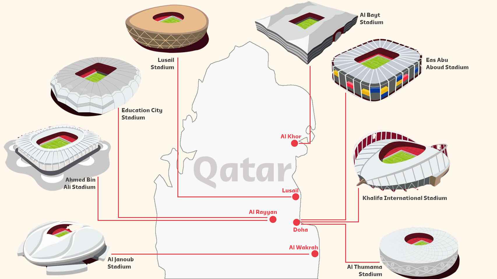

# Descripcion basica de los datos utilizados

El objetivo de los siguientes datos, es realizar un análisis exploratorio para examinar las distintas métricas de interés relacionadas a los aspirantes a ganar la Copa del Mundo que se dará en Qatar 2022. En el cual, a través de la visualización de los datos recopilados en cada Copa del Mundo desde su inicio en Uruguay 1930 se puede conocer la evolución de las selecciones participantes.

En este sentido se usará como librería principal `tidyverse` para proceder con la limpieza y análisis de los datos. Consecutivamente, la librería `dplyr` para mantener la gramática del código ejecutado y la librería `readr` para la importación de los archivos en formato *.cvs*. Por último, la librería `ggplot2` permitió realizar las distintas graficas para la visualización de los datos en conjunto con las librerías `ggthemes` y `gganimate` para la optimización de los gráficos y `reactablefmtr`para las tablas.

```r
library(tidyverse)
```

```r
library(dplyr)
library(readr)
library(ggplot2)
library(ggthemes)
library(gganimate)
library(reactablefmtr)
```

## Fuente

En cuanto a la fuente de recopilación de los datos desde el Archivo de la Copa Mundial de la FIFA y RSSSF, se comparte todos los partidos de las copas mundiales anteriores, las clasificaciones en partidos internacionales y los grupos concebidos para el actual torneo permitiendo crear una serie de datos que permitan mediante la visualización de datos una expectativa de Qatar 2022. Para obtener la data usada en la presentación se usó un repositorio de datos en el siguiente sitio web **[Mavenanalytics](https://www.mavenanalytics.io/blog/maven-world-cup-challenge)** en él se disponen internamente de un *zip file* un total de 6 tablas en formato *.CVS* con el que se albergan las Data set correspondientes para su análisis.

```r
world_cup_matches <- read_csv("World+Cup/world_cup_matches.csv")
X2022_world_cup_groups <- read_csv("World+Cup/2022_world_cup_groups.csv")
```

## Conceptos pertinentes

Los datos que se alojan en las columnas permiten reconocer el registro de cada selección desde el año 1930. Entre los conceptos que son relevantes para entender el fondo del repositorio de datos se describe los siguientes conceptos:

- Team: Selección nacional del país participante o también conocido como National Team.
- Match: Partido o juego planteado.
- Home: Referencia a un partido en casa.
- Away: Referencia a un partido como visitante.
- Ranking FIFA: es el sistema de clasificación de todas las selecciones registradas en la FIFA institución en el cual considera a través de un sistema de puntaje el nivel de competitividad actual de las selecciones en diversos partidos y competiciones.
- Wins: Cantidad de victorias de una selección en los partidos relacionados a la World Cup.
- Ties: Cantidad de empates de una selección en los partidos relacionados a la World Cup.
- Loss: Cantidad de derrotas de una selección en los partidos relacionados a la World Cup

## Definiciones de indicadores

La definición de los indicadores se encuentra enmarcado desde un tipo de observación sistemática basado en rankings, proporciones, distribuciones y otros tipos de visualizaciones con los datos recolectados en los partidos jugados en ediciones anteriores de la Copa del Mundo para ello este segmento reside en tomar en cuenta la experiencia y los datos estadísticos de las 32 selecciones según la interrogante a considerar tomando en cuenta el uso de estadísticas descriptivas para el análisis y entendimiento de los resultados.

## Cantidad de observaciones y cantidad de variables encontradas

Durante esta primera exploración la cantidad de observaciones dentro del paquete de datos obtenidos anteriormente, el primer archivo a gestionar consta de 900 observaciones y 10 variables en el archivo *“World Cup Matches.cvs”* en él se detalla las variables `ID, Year, Date, Stage, Home Team, Home Goals, Away Goals, Away Team, Win Conditions y Host Team.` Es relevante resaltar que en cuanto a valores faltantes dentro de esta tabla se encontró dentro de la columna de Win Conditions solo *N/A.* Esto se puede observar en la parte inferior.

```r
head(world_cup_matches)
```

```
## # A tibble: 6 × 10
##      ID  Year Date       Stage   Home …¹ Home …² Away …³ Away …⁴ Win C…⁵ Host …⁶
##   <dbl> <dbl> <date>     <chr>   <chr>     <dbl>   <dbl> <chr>   <chr>   <lgl>
## 1     1  1930 1930-07-13 Group … France        4       1 Mexico  <NA>    FALSE
## 2     2  1930 1930-07-13 Group … United…       3       0 Belgium <NA>    FALSE
## 3     3  1930 1930-07-14 Group … Yugosl…       2       1 Brazil  <NA>    FALSE
## 4     4  1930 1930-07-14 Group … Romania       3       1 Peru    <NA>    FALSE
## 5     5  1930 1930-07-15 Group … Argent…       1       0 France  <NA>    FALSE
## 6     6  1930 1930-07-16 Group … Chile         3       0 Mexico  <NA>    FALSE
## # … with abbreviated variable names ¹`Home Team`, ²`Home Goals`, ³`Away Goals`,
## #   ⁴`Away Team`, ⁵`Win Conditions`, ⁶`Host Team`
```

Posteriormente, se hizo uso del archivo denominado *“World Cup Groups.cvs”* en el cual detalla las variables `Group, Team y FIFA Ranking` como igualmente se observa en la parte inferior y que consta de 32 observaciones y 03 variables en el archivo.

```r
head(X2022_world_cup_groups)
```

```
## # A tibble: 6 × 3
##   Group Team        `FIFA Ranking`
##   <chr> <chr>                <dbl>
## 1 A     Qatar                   50
## 2 A     Ecuador                 44
## 3 A     Senegal                 18
## 4 A     Netherlands              8
## 5 B     England                  5
## 6 B     Iran                    20
```

# Desarrollo del topico

Como parte del desarrollo de las métricas de interés de los equipos aspirantes a ganar la Copa del Mundo Qatar 2022 se gestionan una serie de interrogantes relacionadas al contexto de la sede, la experiencia de las selecciones participantes y el rendimiento de los jugadores que harán vida en el torneo.

## Justificación

El deporte une a las masas y el futbol desde sus inicios no ha sido exento a ello, desde su institucionalización en 1860 separándose del Rugby como juego se crea la primera asociación del futbol. Ya para el año 1904 ante el aumento de la popularidad de este deporte surge como ente regulador la Federación Internacional de Futbol Asociación conocido popularmente como la FIFA en el cual su primer campeonato acreditada como la Copa del Mundo Uruguay 1930 con la participación tan solo 4 selecciones europeas. En la actualidad, el significado del futbol como deporte no ha variado mucho. Sin embargo, la relevancia económica, social y cultura que representa la FIFA como institución y el futbol en cada nación posee un impacto digno de ser estudiado en cada faceta en este caso será netamente deportivo.

## Cuestiones Planteadas

Para entender el futbol es importante conocer quienes juegan, quienes son los favoritos, cuando gana y cuando pierde. Las interrogantes planteadas responden a la narrativa de obtener un panorama general de las selecciones previo a Qatar 2022 por lo que las cuestiones planteadas se responderán a medida que surge cada interrogante. Iniciamos examinando a las selecciones con más goles en el Torneo FIFA World Cup desde su inicio con la carga de datos anteriormente descriptos para facilitar la lectura de los datos. en tanto se puede apreciar en el registro de la siguiente tabla todos los goles registrados desde el primer torneo en orden descendete de las selecciones que participaron anteriormente.

## Total de goles en todas las selecciones en el torneo FIFA World Cup desde el primer torneo oficial en Uruguay 1930

```r
# Total de goles en todas las selecciones en el torneo FIFA World Cup desde el primer torneo oficial en Uruguay 1930

# Separacion de la tabla por equipo segun los goles obtenidos en el torneo
wcup_goal <- world_cup_matches[c("Home Team", "Home Goals","Away Goals", "Away Team")]

# Creacion de una nueva columna en el data frame
team_column <- c("Team", "Goals")

# filtro y asignacion de goles obtenidos en condicion de Home dentro de team_column
h_cup <- wcup_goal %>%
  group_by(`Home Team`) %>%
  summarise(`Home Goals` = sum(`Home Goals`),
            )
colnames(h_cup) <- c("Team", "Home")

# filtro y asignacion de goles obtenidos en condicion de Away dentro de team_column
a_cup <- wcup_goal %>%
  group_by(`Away Team`) %>%
  summarise(`Away Goals` = sum(`Away Goals`),
  )
colnames(a_cup) <- c("Team", "Away")

# Union y reodenamiento de las tablas de goles obtenidos en un orden descendente
total_gol <- merge(h_cup, a_cup, by = "Team", all = TRUE)
total_gol$total <- total_gol$Home + total_gol$Away
total_gol <- total_gol[with(total_gol, order(-total)), ]
```

```r
# Tabla 1 "Total de goles en todas las selecciones en el torneo FIFA World Cup desde el primer torneo oficial en Uruguay 1930"
reactable(
  total_gol,
  defaultSorted = "total",
  defaultSortOrder = "desc",
  defaultColDef = colDef(
    cell = data_bars(total_gol, text_position = "outside-base")
  )
)
```

| Team | Home | Away | total |
| --- | --- | --- | --- |
| Brazil | 176 | 53 | 229 |
| Germany | 173 | 53 | 226 |
| Argentina | 110 | 27 | 137 |
| Italy | 91 | 37 | 128 |
| France | 81 | 39 | 120 |
| Spain | 53 | 46 | 99 |
| England | 58 | 33 | 91 |
| Hungary | 73 | 14 | 87 |
| Uruguay | 65 | 22 | 87 |
| Netherlands | 48 | 38 | 86 |

[output cut: 71 more lines]

Tal como se refleja en los primeros 10 datos de la tabla desde las variables `Team`, `Home`, `Away` y `total`. Se observa las selecciones con mayor cantidad de goles, a su vez, se ejecuta la sumatoria histórica de los goles en cada selección en base a todas sus participaciones comprimiendo a las ultimas posiciones a las selecciones con menor cantidad de anotaciones.